# First Lasso experiments

Set.seed was set to 4 to make results reproducable

The used data is from river ‘Havel’: “/Data_preprocess/Daten_TestPackage_Berlin/Havel/DATA_preprocessed_csv”

It is taken from the data folder provided by Wolfgang and has the following structure

```r
glimpse(data)
```

```
Rows: 36
Columns: 31
$ log_e.coli         <dbl> 2.100371, 2.428135, 2.252853, 2.838849, 1.662758, 1.785330, 1.477121, 1.662758, 1.973128, 2.04139…
$ ka_mean_mean_12    <dbl> 38.0145, 69.7390, 0.0000, 109.7215, 32.4950, 36.6505, 93.6635, 2.3190, 41.2145, 0.0000, 86.5625, …
$ ka_mean_mean_123   <dbl> 25.34300000, 108.61533333, 0.00000000, 85.48100000, 21.66333333, 24.43366667, 99.35733333, 1.5460…
$ ka_mean_mean_1234  <dbl> 19.00725, 86.94825, 0.00000, 97.09825, 19.73725, 21.00175, 74.51800, 25.04075, 20.60725, 59.98625…
$ ka_mean_mean_12345 <dbl> 15.2058, 79.3838, 13.3450, 84.9316, 17.4996, 18.4878, 59.6144, 38.3930, 29.9036, 64.1680, 132.633…
$ ka_mean_mean_2345  <dbl> 17.36950, 70.51750, 16.68125, 74.91325, 5.62700, 19.21325, 50.63675, 47.99125, 37.37950, 80.21000…
$ ka_mean_mean_345   <dbl> 0.0000000, 85.8136667, 22.2416667, 68.4050000, 7.5026667, 6.3793333, 36.9150000, 62.4423333, 22.3…
$ ka_mean_mean_45    <dbl> 0.0000, 35.5365, 33.3625, 84.1075, 11.2540, 9.5690, 0.0000, 93.6635, 33.5445, 147.8315, 104.8690,…
$ ka_mean_mean_234   <dbl> 23.15933333, 77.64800000, 0.00000000, 87.79600000, 4.65300000, 22.80700000, 67.51566667, 33.38766…
$ ka_mean_mean_23    <dbl> 34.7390, 105.4985, 0.0000, 65.7190, 0.0000, 28.8575, 101.2735, 2.3190, 41.2145, 12.5885, 210.6935…
$ ka_mean_mean_34    <dbl> 0.0000, 104.1575, 0.0000, 84.4750, 6.9795, 5.3530, 55.3725, 47.7625, 0.0000, 119.9725, 245.0200, …
$ q_mean_mean_12     <dbl> 61.650, 75.150, 68.300, 80.300, 66.950, 25.850, 37.250, 38.300, 43.000, 85.400, 129.000, 114.000,…
$ q_mean_mean_123    <dbl> 61.433333, 75.166667, 70.566667, 78.166667, 65.933333, 25.600000, 33.766667, 40.333333, 41.733333…
```

[output cut: 18 more lines]

The prebuild list of 31 averaged variables/features are increased through interactions between each other. This is done by building all interaction formulars with “formula(paste(part1,” ~ (.)^2“)” So every feature besides e.coli will be multiplied with every other feature which leads to 466 features from which the Lasso-algorithms are selecting the most important.

here is an insight of the last 50 formulas

```r
 tail(get_formula_variable_names(form,data), 50)
```

```
 [1] "q_mean_mean_34:r_mean_mean_345"     "q_mean_mean_34:r_mean_mean_45"      "q_mean_mean_34:r_mean_mean_234"
 [4] "q_mean_mean_34:r_mean_mean_23"      "q_mean_mean_34:r_mean_mean_34"      "r_mean_mean_12:r_mean_mean_123"
 [7] "r_mean_mean_12:r_mean_mean_1234"    "r_mean_mean_12:r_mean_mean_12345"   "r_mean_mean_12:r_mean_mean_2345"
[10] "r_mean_mean_12:r_mean_mean_345"     "r_mean_mean_12:r_mean_mean_45"      "r_mean_mean_12:r_mean_mean_234"
[13] "r_mean_mean_12:r_mean_mean_23"      "r_mean_mean_12:r_mean_mean_34"      "r_mean_mean_123:r_mean_mean_1234"
[16] "r_mean_mean_123:r_mean_mean_12345"  "r_mean_mean_123:r_mean_mean_2345"   "r_mean_mean_123:r_mean_mean_345"
[19] "r_mean_mean_123:r_mean_mean_45"     "r_mean_mean_123:r_mean_mean_234"    "r_mean_mean_123:r_mean_mean_23"
[22] "r_mean_mean_123:r_mean_mean_34"     "r_mean_mean_1234:r_mean_mean_12345" "r_mean_mean_1234:r_mean_mean_2345"
[25] "r_mean_mean_1234:r_mean_mean_345"   "r_mean_mean_1234:r_mean_mean_45"    "r_mean_mean_1234:r_mean_mean_234"
[28] "r_mean_mean_1234:r_mean_mean_23"    "r_mean_mean_1234:r_mean_mean_34"    "r_mean_mean_12345:r_mean_mean_2345"
[31] "r_mean_mean_12345:r_mean_mean_345"  "r_mean_mean_12345:r_mean_mean_45"   "r_mean_mean_12345:r_mean_mean_234"
[34] "r_mean_mean_12345:r_mean_mean_23"   "r_mean_mean_12345:r_mean_mean_34"   "r_mean_mean_2345:r_mean_mean_345"
[37] "r_mean_mean_2345:r_mean_mean_45"    "r_mean_mean_2345:r_mean_mean_234"   "r_mean_mean_2345:r_mean_mean_23"
[40] "r_mean_mean_2345:r_mean_mean_34"    "r_mean_mean_345:r_mean_mean_45"     "r_mean_mean_345:r_mean_mean_234"
[43] "r_mean_mean_345:r_mean_mean_23"     "r_mean_mean_345:r_mean_mean_34"     "r_mean_mean_45:r_mean_mean_234"
[46] "r_mean_mean_45:r_mean_mean_23"      "r_mean_mean_45:r_mean_mean_34"      "r_mean_mean_234:r_mean_mean_23"
[49] "r_mean_mean_234:r_mean_mean_34"     "r_mean_mean_23:r_mean_mean_34"
```

The features are getting selected through the lasso algorithm with cross validation without (1.row - graphs below) or with (2.row - graphs below) internal standardization of the features

The following 4 graphs show the the number of selected features (upper scale) dependend on log lambda (lower scale) The left dotted line shows the lambda with the minimal MSE - identified throug cross-validation The right dotted line shows the lambda 1 standard deviation away from the with the minimal MSE - identified throug cross-validation (shall give a better generalization than minimum mse)

```r
 par(mfrow=c(2,2))
    plot(fit_lasso_base, xvar="lambda", label = T, main = "lasso_base")
    plot(fit_lasso_base_cross,main="LASSO")
```

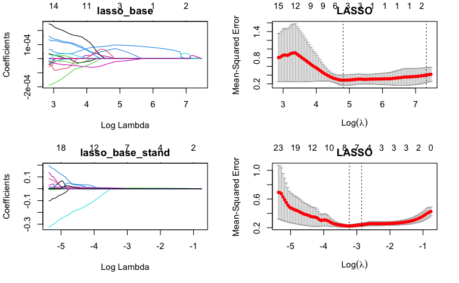

```r
    plot(fit_lasso_base_stand, xvar="lambda", label = T, main = "lasso_base_stand")
    plot(fit_lasso_base_cross_stand,main="LASSO")
```

Selected coefficients with lambda-1se for lasso base cross

```r
get_coef_1se_cv(fit_lasso_base_cross)$name
```

```
[1] "(Intercept)"                    "q_mean_mean_123:q_mean_mean_23"
```

Selected coefficients with lambda-1se for lasso base cross standardized

```r
get_coef_1se_cv(fit_lasso_base_cross_stand)$name
```

```
[1] "(Intercept)"                      "q_mean_mean_2345"                 "ka_mean_mean_12:ka_mean_mean_123"
[4] "ka_mean_mean_12:ka_mean_mean_34"  "q_mean_mean_12:r_mean_mean_12"    "q_mean_mean_45:r_mean_mean_12"
[7] "q_mean_mean_45:r_mean_mean_12345" "q_mean_mean_45:r_mean_mean_45"
```

9 different models were build in the very first code snippet (suppressed in html but visible in notebook): - 5 from stepwise regression, with 1-5 explanatory variables (choosen with Information Criterion) - 4 Lasso based models:

from the two cross validated lasso fits: fit_lasso_base_cross and fit_lasso_base_cross_stand (with internal standardization of features) I used lambda min and lambda-1se to get 4 lasso based models with the following modelnumbers: 06: fit_lasso_base_cross lambda-1se 07: fit_lasso_base_cross_stand lambda-1se 08: fit_lasso_base_cross lambda-min 09: fit_lasso_base_cross_stand lambda-min

The 4 Lasso based models were than used in the posterior function for validation. If in50, below90, below95, and in 95 are all == 5 –> the model is validated through the validation method from wolfgang.

The best Model was chosen by further checking statistical correctness and sorting R2 in descending order.

```r
sorted_modellist
```

| river | model | N | BP | R2 | n_obs | stat_correct | in50 | below90 | below95 | in95 |
| --- | --- | --- | --- | --- | --- | --- | --- | --- | --- | --- |
| 1 | havelmodel_09 | 0.5687379214 | 0.15529868 | 0.6965679 | 36 | TRUE | 5 | 5 | 5 | 5 |
| 1 | havelmodel_07 | 0.7561300837 | 0.08067669 | 0.6805674 | 36 | TRUE | 5 | 5 | 5 | 5 |
| 1 | havelmodel_05 | 0.0831787192 | 0.39050913 | 0.6542907 | 36 | TRUE | 5 | 5 | 5 | 5 |
| 1 | havelmodel_04 | 0.0222017957 | 0.36522362 | 0.6359124 | 36 | FALSE | 5 | 5 | 5 | 5 |
| 1 | havelmodel_08 | 0.0005064489 | 0.51380533 | 0.5905264 | 36 | FALSE | 5 | 5 | 5 | 5 |
| 1 | havelmodel_03 | 0.0494852944 | 0.02252424 | 0.5602121 | 36 | FALSE | 5 | 5 | 5 | 5 |
| 1 | havelmodel_06 | 0.0159547121 | 0.05243460 | 0.4226691 | 36 | FALSE | 5 | 5 | 5 | 5 |
| 1 | havelmodel_02 | 0.0845936187 | 0.15287316 | 0.5027969 | 36 | TRUE | 4 | 5 | 5 | 5 |
| 1 | havelmodel_01 | 0.0367864223 | 0.02358498 | 0.4743527 | 36 | FALSE | 4 | 5 | 5 | 5 |

Whats interesting is, that only the standardized models (07 & 09) were able to beat the stepwise builded models with this evaluation method.

Best Model here is havelmodel_09 with the following coefficients:

```r
names(coef(best_valid_model))
```

```
[1] "(Intercept)"                      "q_mean_mean_45"                   "ka_mean_mean_12:ka_mean_mean_123"
[4] "ka_mean_mean_12:ka_mean_mean_34"  "q_mean_mean_12:r_mean_mean_12"    "q_mean_mean_45:r_mean_mean_12"
[7] "q_mean_mean_45:r_mean_mean_1234"  "q_mean_mean_45:r_mean_mean_45"
```